# Machine Learning with `caret` in R (DataCamp)

Nader Hotait

University of Potsdam  
nhotait@uni-potsdam.de

02 August, 2020

## Regression models: fitting them and evaluating their performance

**Supervised vs. Unsupersived Learning**

- Predictive Modeling = Supervised Learning
- Supervised Learning = Machine Learning if you have a target variable
- Two types of predictive modeling
  - Classification (Qualitative)
  - Regression (Quantitative)

**Evaluating Model Perfomance**

- Use *metrics* to evaluate a model. It is:
  - Quantifiable
  - Objective
- *Root Mean Squared Error* (RMSE) for regression
- Common to calculate in-sample RMSE. Problems:
  - Too optimistic since model is trained on the same data that you are calculating RMSE on
  - Leads to overfitting
- Better to calculate out-of-sample error
  - Simulates real world usage
  - Helps avoid overfitting

```r
## Computing the RMSE on the diamonds data set
library(caret)
```

```r
library(ggplot2)
library(tidyverse)
library(dplyr)
data("diamonds")

# Fit lm model: model
model <- lm(price ~ ., diamonds)

# Predict on full data: p
p <- predict(model, type="response")

# Compute errors: error
error <- p - diamonds$price

# Calculate RMSE
sqrt(mean((error)^2))
```

```
## [1] 1129.843
```

**Out-of-sample error measures**

- Objective: Want models that don’t overfit and generalize well ($\neq$ explanatory modeling)
- Do the models perform well on new data?
- Test models on new data, or test set
  - Key insight of machine learning
  - In-sample validation almost guarantees overfitting ==> We try to simulate this by applying a train/test split

```r
## First we randomly shuffle the data so that potential clusters or imbalances are disaggregated
# Set seed so this can be reproduced
set.seed(42)

# Shuffle row indices: rows
rows <- sample(nrow(diamonds))

# Randomly order data
shuffled_diamonds <- diamonds[rows,]

# Determine row to split on: split (at 80%)
split <- round(nrow(shuffled_diamonds)*0.8)

# Create train
train <- shuffled_diamonds[1:split,]

# Create test
test <- shuffled_diamonds[(split+1):nrow(shuffled_diamonds),]

# Fit lm model on train: model
model <- lm(price ~ ., train)

# Predict on test: p
p <- predict(model, test)

# Compute errors: error
error <- p - test$price

# Calculate RMSE
sqrt(mean(error^2))
```

```
## [1] 1137.466
```

```r
# The model is worse than we initially thought!
```

**Cross-validation**

- One simple split is fragile as a process, as one single outlier could cause problems
- Better approach is to have several test done, with: - Equally sized test sets
  - Over k-fold amount of sets (e.g. ten)
  - And averaging out the out-of-sample error measures
- The `train` function (`caret`) can do that for us!

```r
# Fit lm model using 10-fold CV: model
model <- train(
  price ~ .,
  diamonds,
  method = "lm",
  trControl = trainControl(
    method = "cv",
    number = 10,
    verboseIter = TRUE
  )
)
# Print model to console
model
```

```
## Linear Regression
##
## 53940 samples
##     9 predictor
##
## No pre-processing
## Resampling: Cross-Validated (10 fold)
## Summary of sample sizes: 48547, 48546, 48546, 48547, 48545, 48547, ...
## Resampling results:
##
##   RMSE      Rsquared   MAE
##   1131.015  0.9196398  740.6117
##
## Tuning parameter 'intercept' was held constant at a value of TRUE
```

```r
# Fit lm model using 5-fold CV: model
library(MASS)
data(Boston)
model <- train(
  medv ~.,
  Boston,
  method = "lm",
  trControl = trainControl(
    method = "cv",
    number = 5,
    verboseIter = TRUE
  )
)
# Print model to console
model
```

```
## Linear Regression
##
## 506 samples
##  13 predictor
##
## No pre-processing
## Resampling: Cross-Validated (5 fold)
## Summary of sample sizes: 405, 405, 406, 403, 405
## Resampling results:
##
##   RMSE      Rsquared   MAE
##   4.860247  0.7209221  3.398114
##
## Tuning parameter 'intercept' was held constant at a value of TRUE
```

```r
## We can repeat the process of CV ("repeats")
# Fit lm model using 5 x 5-fold CV: model
model <- train(
  medv ~ .,
  Boston,
  method = "lm",
  trControl = trainControl(
    method = "repeatedcv",
    number = 5,
    repeats = 5,
    verboseIter = TRUE
  )
)
# Print model to console
model
```

```
## Linear Regression
##
## 506 samples
##  13 predictor
##
## No pre-processing
## Resampling: Cross-Validated (5 fold, repeated 5 times)
## Summary of sample sizes: 405, 406, 405, 403, 405, 405, ...
## Resampling results:
##
##   RMSE      Rsquared   MAE
##   4.845724  0.7277269  3.402735
##
## Tuning parameter 'intercept' was held constant at a value of TRUE
```

```r
## By using "train" we simultaneously fit a model that we can predict. (model -> list -> final model)

pr <- predict(model, Boston)
head(pr)
```

```
##        1        2        3        4        5        6
## 30.00384 25.02556 30.56760 28.60704 27.94352 25.25628
```

## Classification models: fitting them and evaluating their performance

**Logistic Regression on sonar**

- Classification Models:
  - Categorical (i.e. qualitative) target variable
  - Example: will a loan default?
  - Still a form of supervised learning
  - Use a train/test split to evaluate performance
- Splitting the data:
  - The task will include a logistic regression on the `sonar` data set, to predict rocks/mines.
  - Here we will use a 60/40 split for Cross-Validation

```r
library(mlbench)
data("Sonar")

set.seed(313)
# Get the number of observations
n_obs <- nrow(Sonar)

# Shuffle row indices: permuted_rows
permuted_rows <- sample(n_obs)

# Randomly order data: Sonar
Sonar_shuffled <- Sonar[permuted_rows,]

# Identify row to split on: split
split <- round(n_obs * 0.6)

# Create train
train <- Sonar_shuffled[1:split,]

# Create test
test <- Sonar_shuffled[(split+1):n_obs,]

# Did the split work? Yes!
list(nrow(test)/nrow(Sonar), nrow(train)/nrow(Sonar))
```

```
## [[1]]
## [1] 0.3990385
##
## [[2]]
## [1] 0.6009615
```

```r
# Fit glm model: model
model <- glm(Class ~ ., binomial(link = "logit"), data=train)
## Don't worry of the fit not converging
# Predict on test: p
p <- predict.glm(model, newdata=test, type="response")
```

**Confusion matrix**

We use this to evaluate the performance of a classification model. We display predicted classes vs. actual outcomes Confusion matrix: As whether an outcome got “confused” for anouther. Typically it’ll look like this:

|  |  | **Reference** |  |
| --- | --- | --- | --- |
|  |  | **Yes** | **No** |
| **Prediction** | **Yes** | *True Positives* | *False Positives* |
|  | **No** | *False Negatives* | *True Negatives* |

As we usually predict probabilities in regards to categorical data and not linear predictions (don’t get it confused with the linear combination of the regression model), the objective should be to find a measure to code the probabilities into a binary outcome. Here we can turn the probabilities into classes by choosing a threshold at which a greater value is a positive and a lower value is a negative outcome.

```r
# If p exceeds threshold of 0.5 (50%), M else R: m_or_r
m_or_r <- ifelse(p > 0.5, "M", "R")

# Convert to factor: p_class
p_class <- as.factor(m_or_r)

# Create confusion matrix
confusionMatrix(p_class, test$Class)
```

```
## Confusion Matrix and Statistics
##
##           Reference
## Prediction  M  R
##          M 19 27
##          R 29  8
##
##                Accuracy : 0.3253
##                  95% CI : (0.2265, 0.437)
##     No Information Rate : 0.5783
##     P-Value [Acc > NIR] : 1.0000
##
##                   Kappa : -0.3727
##
##  Mcnemar's Test P-Value : 0.8937
##
##             Sensitivity : 0.3958
##             Specificity : 0.2286
##          Pos Pred Value : 0.4130
##          Neg Pred Value : 0.2162
##              Prevalence : 0.5783
##          Detection Rate : 0.2289
##    Detection Prevalence : 0.5542
##       Balanced Accuracy : 0.3122
##
##        'Positive' Class : M
##
```

```r
### What do we see:
# Accuracy: How correct were we (percentage)
# No Information Rate: How correct would we have been, if we predicted everything as the most dominant class (here Mines)
# Sensitivity: True Positives Rate
# Specificity: True Negatives Rate
```

- Not limited to to 50% threshold
  - 10% would catch more mines with less certainty (higher false positive; higher true positives)
  - 90% would catch fewer mines with more certainty (lower false positive: lower true positives)
- Choosing a threshold means a balance between true positive and false positive rates
- Choosing threshold is dependent on cost-benefit-analysis

```r
# If p exceeds threshold of 0.9 (90%), M else R: m_or_r
m_or_r <- ifelse(p>0.9, "M", "R")

# Convert to factor: p_class
p_class <- as.factor(m_or_r)

# Create confusion matrix
confusionMatrix(p_class, test$Class)
```

```
## Confusion Matrix and Statistics
##
##           Reference
## Prediction  M  R
##          M 18 27
##          R 30  8
##
##                Accuracy : 0.3133
##                  95% CI : (0.2159, 0.4244)
##     No Information Rate : 0.5783
##     P-Value [Acc > NIR] : 1.0000
##
##                   Kappa : -0.3919
##
##  Mcnemar's Test P-Value : 0.7911
##
##             Sensitivity : 0.3750
##             Specificity : 0.2286
##          Pos Pred Value : 0.4000
##          Neg Pred Value : 0.2105
##              Prevalence : 0.5783
##          Detection Rate : 0.2169
##    Detection Prevalence : 0.5422
##       Balanced Accuracy : 0.3018
##
##        'Positive' Class : M
##
```

```r
# If p exceeds threshold of 0.1, M else R: m_or_r
m_or_r <- ifelse(p > 0.1, "M", "R")

# Convert to factor: p_class
p_class <- as.factor(m_or_r)

# Create confusion matrix
confusionMatrix(p_class, test$Class)
```

```
## Confusion Matrix and Statistics
##
##           Reference
## Prediction  M  R
##          M 19 27
##          R 29  8
##
##                Accuracy : 0.3253
##                  95% CI : (0.2265, 0.437)
##     No Information Rate : 0.5783
##     P-Value [Acc > NIR] : 1.0000
##
##                   Kappa : -0.3727
##
##  Mcnemar's Test P-Value : 0.8937
##
##             Sensitivity : 0.3958
##             Specificity : 0.2286
##          Pos Pred Value : 0.4130
##          Neg Pred Value : 0.2162
##              Prevalence : 0.5783
##          Detection Rate : 0.2289
##    Detection Prevalence : 0.5542
##       Balanced Accuracy : 0.3122
##
##        'Positive' Class : M
##
```

**Intoducing the ROC curve**

The challenge with evaluating the performance of a classification model via confusion matrices is to find the right amount of thresholds (many) without arbitrarily running a sequence classifications and ending up overlooking important thresholds.

- The challenge:
  - Many possible classification thresholds
  - Requires manual work to choose
  - Easy to overlook a particular threshold
  - We need a more systematic approach
- ROC Curves:
  - Plot true/false positive rate at every possible threshold
  - Visualize tradeoffs between two extremes (100% true positives vs 0% false positive)
  - Result is an ROC curve

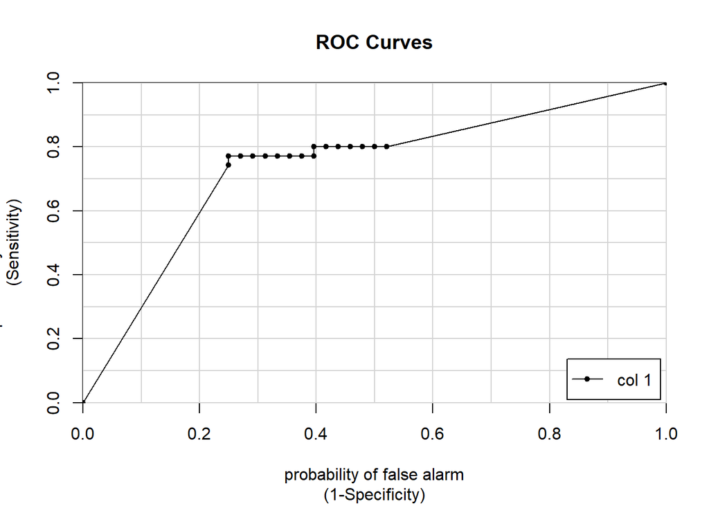

```
##              [,1]
## M vs. R 0.7366071
```

```r
library(caTools)
colAUC(p, test$Class, plotROC = TRUE)
```

```r
# Every point shows us a threshold
# Y-Axis: True positives
# X-Axis: False positives
```

**Area under the curve (AUC)**

- We can say following about the curve itself:
  - Random predictions would follow a (close to) linear line
  - Perfect predictions would create something like a box, where a single point would predict all positives while detecting no false positives. Results in a lot of space under the curve
  - Perfectly incorrect predictions (rarely happen) would create a box with the opposite factum - no true positives all false positives. Results in no space under the curve.
- The area under the curve (AUC) would basically tell us how good model perform. Numerically speaking this would mean:
  - All the space under the curve is available = perfect prediction = Values as 1
  - Half of the space under the curve is available = random prediction = Values as 0.5
  - No space under the curve is available = perfectly false prediction = Values as 0
- Defining AUC as a metric:
  - Single-number summary of model accuracy
  - Summarizes performance accross all thresholds
  - Can be used to rank different models within the same dataset

```r
# Create trainControl object: myControl
# This allows use to feed this to the train function
# We use 10 iterations here for the cross-validation
# we use a twoClassSummary wo the binary outcome to be produced (instead of defaultSummary)
# When choosing twoClassSummary we need to set classProbs on True
# We are trying to get evualuation metrics over a 10-fold cross validation and averaging them out.
myControl <- trainControl(
  method = "cv",
  number = 10,
  summaryFunction = twoClassSummary,
  classProbs = TRUE, # IMPORTANT!
  verboseIter = TRUE
)

# Train glm with custom trainControl: model
model <- train(Class ~., Sonar, method="glm", trControl=myControl)
# Print model to console
model
```

```
## Generalized Linear Model
##
## 208 samples
##  60 predictor
##   2 classes: 'M', 'R'
##
## No pre-processing
## Resampling: Cross-Validated (10 fold)
## Summary of sample sizes: 188, 187, 188, 187, 187, 187, ...
## Resampling results:
##
##   ROC        Sens       Spec
##   0.7202399  0.7287879  0.6944444
```

```r
# ROC is aight but not amazing. Better than random.
```

## Tuning model parameters to improve performance

**Random forests and wine**

- Random forest
  - Popular type of machien learning model
  - Good for beginners
  - Robust to overfitting
  - Yield very accurate, non-linear models
  - Default values often OK, but occasionally need adjustment
  - These adjustments on hyperparameters need to be manually justified, unlike other methods like the slope in a linear model
- What does it do?
  - Start with a simple desicion tree
  - Decision trees are fast, but not very accurate
  - Random forests improve accuracy by fitting many trees
  - Fit each one to a bootstrap sample of your data
  - Called *bootstrap aggregation* or *bagging*
  - Randomly sample columns at each split. Meaning what information the decision split will be based on (randomly)
  - Each individual tree in the random forest spits out a class prediction and the class with the most votes becomes our model’s prediction

```r
white.url <- "https://archive.ics.uci.edu/ml/machine-learning-databases/wine-quality/winequality-white.csv"
white.raw <- read.csv(white.url, header = TRUE, sep = ";")
wine <- white.raw
glimpse(wine)
```

```
## Rows: 4,898
## Columns: 12
## $ fixed.acidity        <dbl> 7.0, 6.3, 8.1, 7.2, 7.2, 8.1, 6.2, 7.0, 6.3, 8...
## $ volatile.acidity     <dbl> 0.27, 0.30, 0.28, 0.23, 0.23, 0.28, 0.32, 0.27...
## $ citric.acid          <dbl> 0.36, 0.34, 0.40, 0.32, 0.32, 0.40, 0.16, 0.36...
## $ residual.sugar       <dbl> 20.70, 1.60, 6.90, 8.50, 8.50, 6.90, 7.00, 20....
## $ chlorides            <dbl> 0.045, 0.049, 0.050, 0.058, 0.058, 0.050, 0.04...
## $ free.sulfur.dioxide  <dbl> 45, 14, 30, 47, 47, 30, 30, 45, 14, 28, 11, 17...
## $ total.sulfur.dioxide <dbl> 170, 132, 97, 186, 186, 97, 136, 170, 132, 129...
## $ density              <dbl> 1.0010, 0.9940, 0.9951, 0.9956, 0.9956, 0.9951...
## $ pH                   <dbl> 3.00, 3.30, 3.26, 3.19, 3.19, 3.26, 3.18, 3.00...
## $ sulphates            <dbl> 0.45, 0.49, 0.44, 0.40, 0.40, 0.44, 0.47, 0.45...
## $ alcohol              <dbl> 8.8, 9.5, 10.1, 9.9, 9.9, 10.1, 9.6, 8.8, 9.5,...
## $ quality              <int> 6, 6, 6, 6, 6, 6, 6, 6, 6, 6, 5, 5, 5, 7, 5, 7...
```

```r
# Fit random forest: model
library(ranger)
model <- train(
  quality ~ .,
  tuneLength = 1, ## The total number of unique combinations -> Basically how many models to use from variables
  data = wine,
  method = "ranger", ## This is the package we use for RF, instead of randomForest
  trControl = trainControl( ## With a cross validation
    method = "cv",
    number = 5,
    verboseIter = TRUE
  )
)
# Print model to console
model
```

```
## Random Forest
##
## 4898 samples
##   11 predictor
##
## No pre-processing
## Resampling: Cross-Validated (5 fold)
## Summary of sample sizes: 3918, 3918, 3919, 3919, 3918
## Resampling results across tuning parameters:
##
##   splitrule   RMSE       Rsquared   MAE
##   variance    0.6091637  0.5342693  0.4395956
##   extratrees  0.6184236  0.5304142  0.4575555
##
## Tuning parameter 'mtry' was held constant at a value of 3
## Tuning
##  parameter 'min.node.size' was held constant at a value of 5
## RMSE was used to select the optimal model using the smallest value.
## The final values used for the model were mtry = 3, splitrule = variance
##  and min.node.size = 5.
```

**Explore a wider model space**

- Random forests require tuning
  - Hyperparameters control how the model is fit
  - Selected “by hand” before the model is fit
  - Most important is `mtry`
    - Number of randomly selected variables used at each split
    - “Randomly sample columns at each split” as I mentioned above
  - Lower `mtry` value = more random (more to choose)
  - Higher `mtry` value = less random (less to choose)
  - Hard to know the best value in advance

The `train` function automatically models for different values of `mtry` for us to inspect and choose. It automatically fits a final model with the optimal parameters (see the report of the command or `model[["finalModel"]]`). The results below show us: `extraTreets` as a splitting rule, implementing [Extra randomized trees](https://link.springer.com/article/10.1007/s10994-006-6226-1), performs worse than `variance`. A value of 6 for `mtry` (randomly selected predictors) seems to be the best option to minimize errors (RMSE).

```r
# Fit random forest: model
model <- train(
  quality ~.,
  tuneLength = 3,
  data = wine,
  method = "ranger",
  trControl = trainControl(
    method = "cv",
    number = 5,
    verboseIter = TRUE
  )
)
# Print model to console
model
```

```
## Random Forest
##
## 4898 samples
##   11 predictor
##
## No pre-processing
## Resampling: Cross-Validated (5 fold)
## Summary of sample sizes: 3918, 3919, 3919, 3918, 3918
## Resampling results across tuning parameters:
##
##   mtry  splitrule   RMSE       Rsquared   MAE
##    2    variance    0.6073516  0.5408002  0.4418424
##    2    extratrees  0.6240174  0.5284146  0.4668256
##    6    variance    0.6062492  0.5360503  0.4367816
##    6    extratrees  0.6110077  0.5352389  0.4481644
##   11    variance    0.6098669  0.5286386  0.4385210
##   11    extratrees  0.6113823  0.5306573  0.4458735
##
## Tuning parameter 'min.node.size' was held constant at a value of 5
## RMSE was used to select the optimal model using the smallest value.
## The final values used for the model were mtry = 6, splitrule = variance
##  and min.node.size = 5.
```

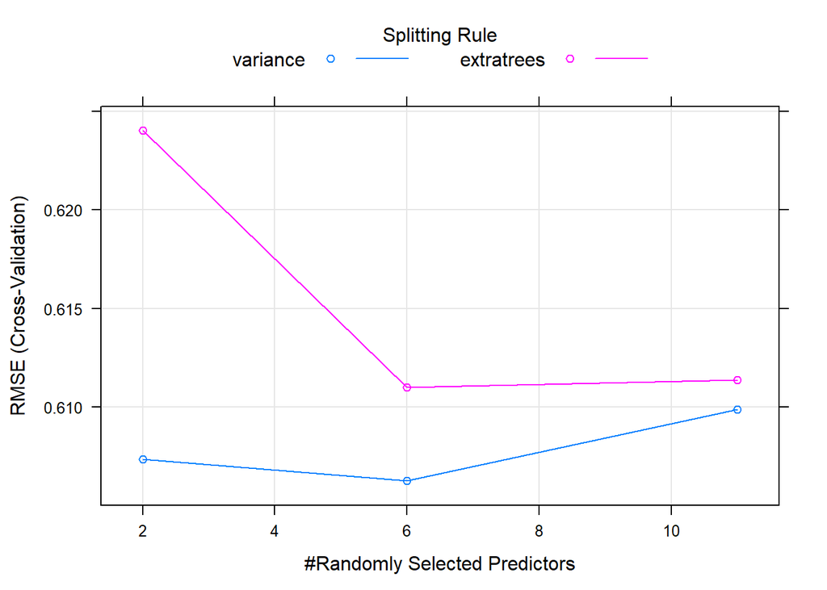

```r
# Plot model
plot(model)
```

**Custom tuning grids**

We are not bound to the default settings of the tuning grids Pros and cons of custom tuning:

- Pass custom tuning grids to `tuneGrid` argument
- Advantages
  - Most flexible method for fitting `caret` models
  - Complete control over how the model is fit
- Disadvantages
  - Requires some knowledge of the model
  - Can dramatically increase run time

```r
# Define the tuning grid: tuneGrid
tuneGrid <- data.frame(
  .mtry = c(2,3,7),        ## Custom rangeo of mtry to explore
  .splitrule = "variance", ## One split rule
  .min.node.size = 5       ## Minimum number of observations in a terminal node
)

# Fit random forest: model
model <- train(
  quality ~.,
  tuneGrid = tuneGrid,     ## Here we insert our custom tuneGrid
  data = wine,
  method = "ranger",
  trControl = trainControl(
    method = "cv",
    number = 5,
    verboseIter = TRUE
  )
)
# Print model to console
model
```

```
## Random Forest
##
## 4898 samples
##   11 predictor
##
## No pre-processing
## Resampling: Cross-Validated (5 fold)
## Summary of sample sizes: 3918, 3919, 3919, 3918, 3918
## Resampling results across tuning parameters:
##
##   mtry  RMSE       Rsquared   MAE
##   2     0.6076327  0.5404664  0.4414114
##   3     0.6074834  0.5375631  0.4389516
##   7     0.6095768  0.5307787  0.4376825
##
## Tuning parameter 'splitrule' was held constant at a value of variance
##
## Tuning parameter 'min.node.size' was held constant at a value of 5
## RMSE was used to select the optimal model using the smallest value.
## The final values used for the model were mtry = 3, splitrule = variance
##  and min.node.size = 5.
```

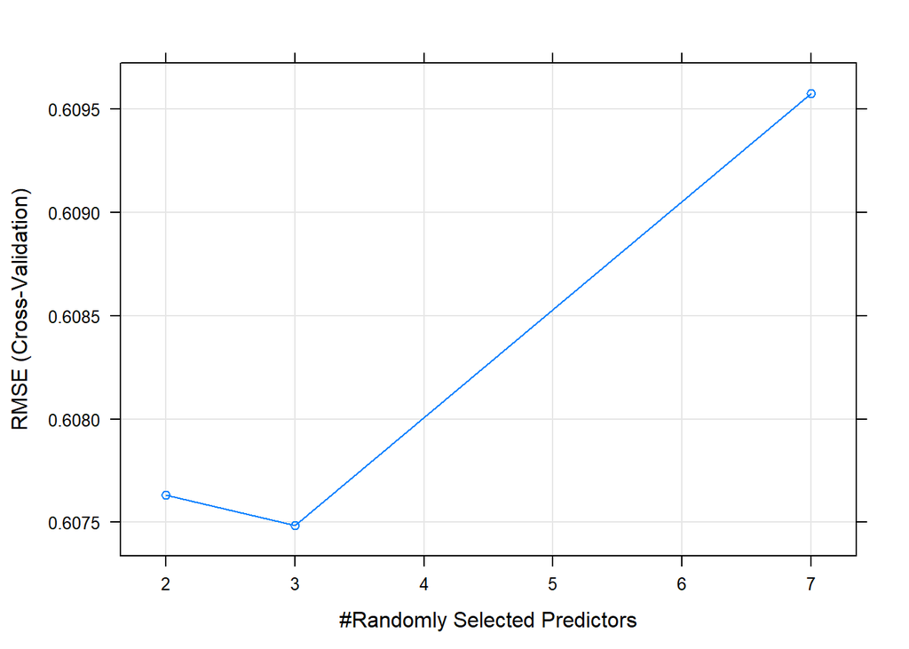

```r
# Plot model
plot(model)
```

**glmnet**

Introducing glmnet:

- Extension of glm models with built-in variable selection
- Helps deal with collinearity and small samples sizes
- Two primary forms
  - Lasso regression: penalizes number of non-zero coefficients (resulting in a few non-zero coef.)
  - Ridge regression: penalizes absolute magnitude of coefficients (small absolute magnitude coefficients)
- Attempts to find a parsimonious (i.e. simple) model
- Pairs well with random forest models

Tuning glmnet models:

- Combination of lasso and ridge regression
- Can fit a mix of the models, thas is a model with a small penalty on both the:
  - number of non-zero coefficients
  - and their absolute magnitude
- Therefore there are many parameters to tune:
  - `alpha [0,1]`: pure ridge (0) to pure lasso (1)
  - `lambda (0,infinity)`: size of the penalty. The higher the value to smaller the value. Hence, if we tune the number large enough there would be an intercept only model

The results below show an optimal model at alpha = 1 (lasso) and lambda (penality) of 0.029900470

```r
# Create custom trainControl: myControl
myControl <- trainControl(
  method = "cv",
  number = 10,
  summaryFunction = twoClassSummary,
  classProbs = TRUE, # IMPORTANT!
  verboseIter = TRUE
)

# Fit glmnet model with the overfit data: model
overfit <- read.csv("train.csv")
overfit <- overfit[,-1]
names(overfit)[names(overfit)=="target"] <- "y"
overfit$y[overfit$y == "0"] <- "class1"
overfit$y[overfit$y == "1"] <- "class2"
names(overfit)[names(overfit)=="X0"] <- "X300"
overfit$y <- as.factor(overfit$y)

model <- train(
  y~.,
  overfit,
  method = "glmnet",
  trControl = myControl
)
# Print model to console
model
```

```
## glmnet
##
## 250 samples
## 300 predictors
##   2 classes: 'class1', 'class2'
##
## No pre-processing
## Resampling: Cross-Validated (10 fold)
## Summary of sample sizes: 224, 225, 225, 226, 225, 225, ...
## Resampling results across tuning parameters:
##
##   alpha  lambda       ROC        Sens       Spec
##   0.10   0.009455359  0.6560777  0.8359649  0.3309524
##   0.10   0.029900470  0.6624826  0.8634503  0.3166667
##   0.10   0.094553588  0.6846561  0.9286550  0.2238095
##   0.55   0.009455359  0.6882693  0.8304094  0.3452381
##   0.55   0.029900470  0.7365149  0.9283626  0.3166667
##   0.55   0.094553588  0.7466722  0.9944444  0.0452381
##   1.00   0.009455359  0.7230089  0.8517544  0.3476190
##   1.00   0.029900470  0.7744013  0.9339181  0.2404762
##   1.00   0.094553588  0.7122180  1.0000000  0.0000000
##
## ROC was used to select the optimal model using the largest value.
## The final values used for the model were alpha = 1 and lambda = 0.02990047.
```

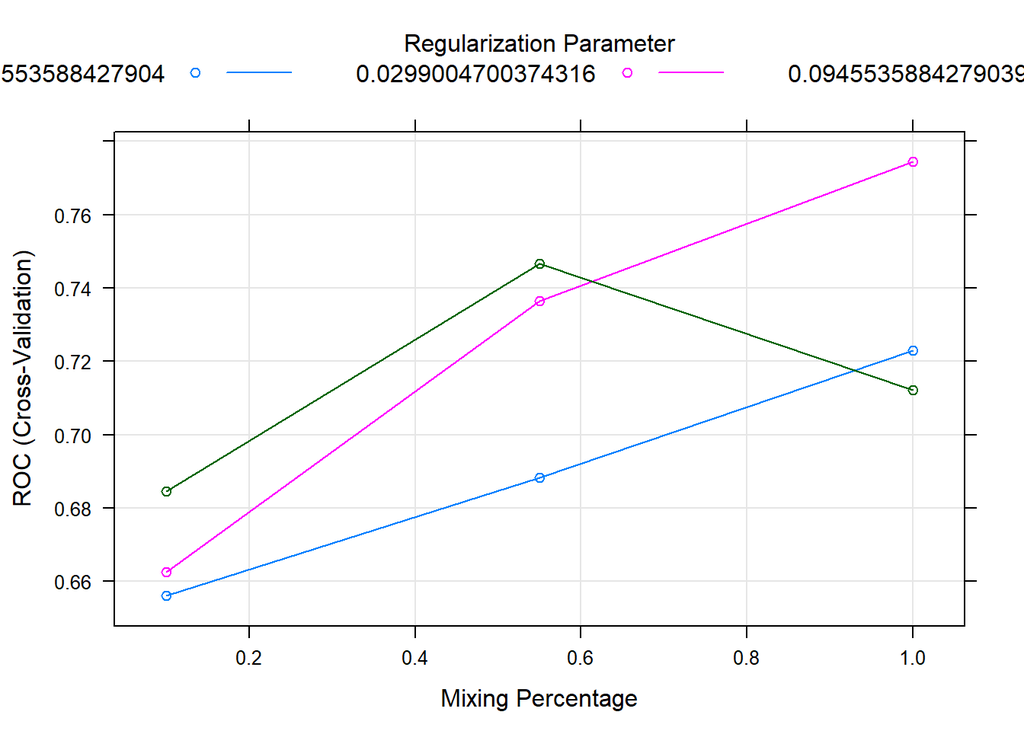

```r
# Plotting the model
plot(model)
```

```r
# Print maximum ROC statistic
max(model$results[["ROC"]])
```

```
## [1] 0.7744013
```

**glmnet with custom tuning grid**

- random forest had only one tuning param.: mtry
- glmnet has two: alpha and lambda
- for single alpha, all values of lambda fit simultaneously (fits several alpha in one alpha model)
- Many models for the “price” of one